# Time Series Forecasting

chandrakanth

May 17, 2019

## Loading Required Libraries

## Dataset

This dataset describes the minimum daily temperatures over 10 years (1981-1990) in the city Melbourne, Australia. The units are in degrees Celsius and there are 3650 observations. The source of the data is credited as the Australian Bureau of Meteorology.

```
##       Date                 Temp
##  Min.   :1981-01-01   Min.   : 0.00
##  1st Qu.:1983-07-02   1st Qu.: 8.30
##  Median :1985-12-31   Median :11.00
##  Mean   :1985-12-31   Mean   :11.18
##  3rd Qu.:1988-06-30   3rd Qu.:14.00
##  Max.   :1990-12-31   Max.   :26.30
```

## Creating Date Time Variables

## Looking at the seasonal trends

As we can see from the graph below there seems to be a clear pattern in terms of how the temperature various over the years

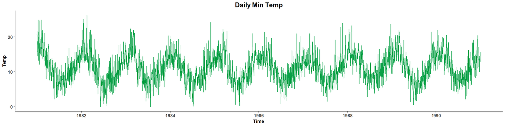

If we look more closely there are a lot more hidden patterns as shown below.

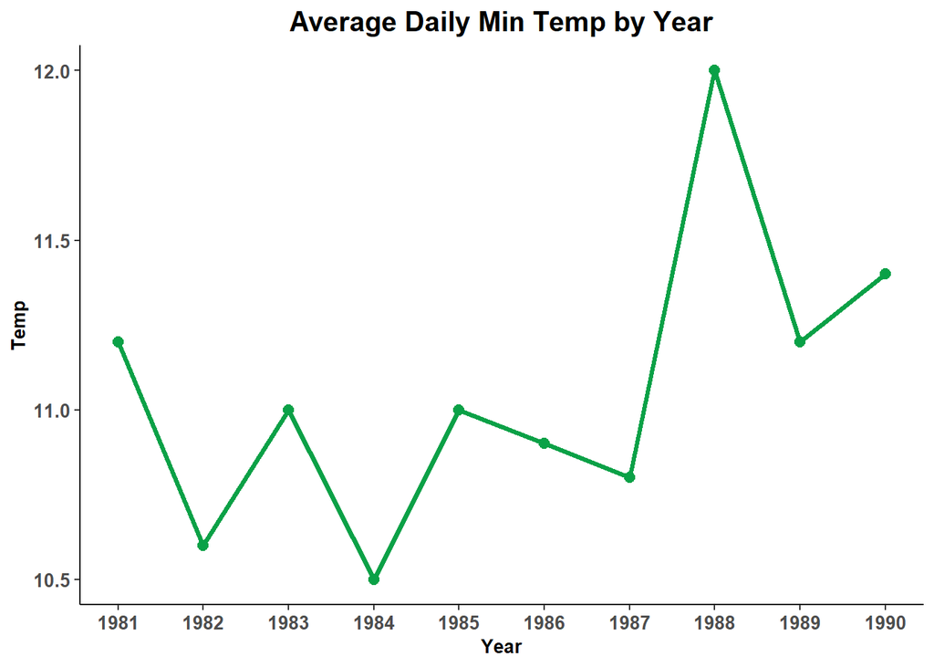

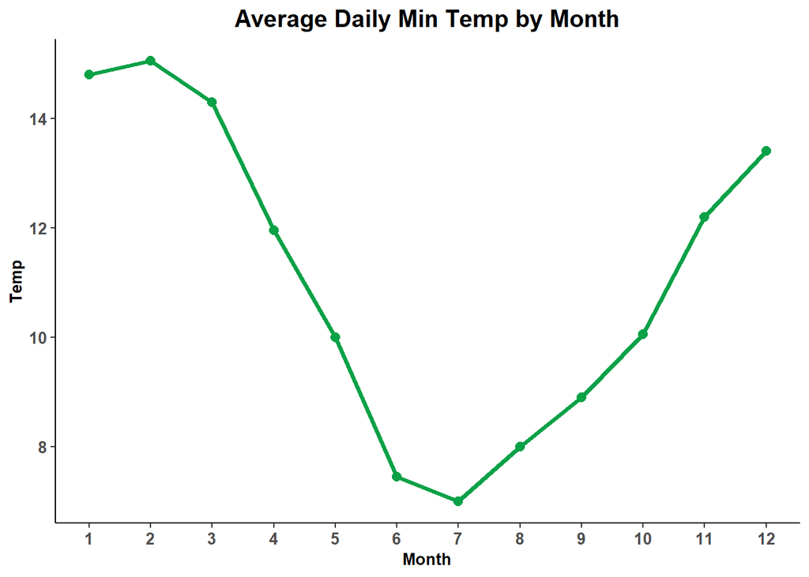

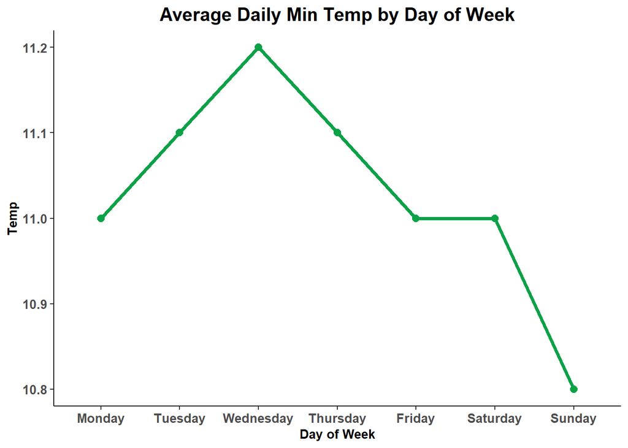

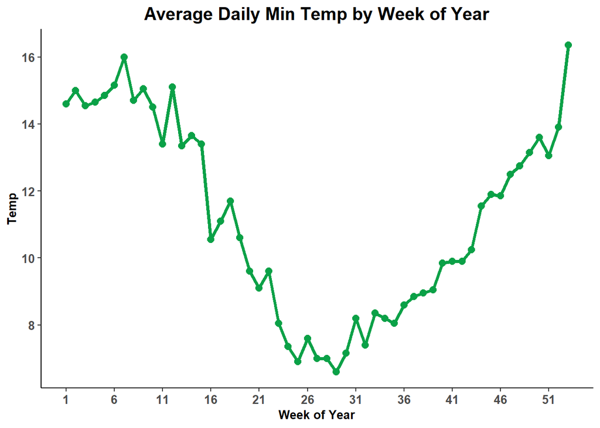

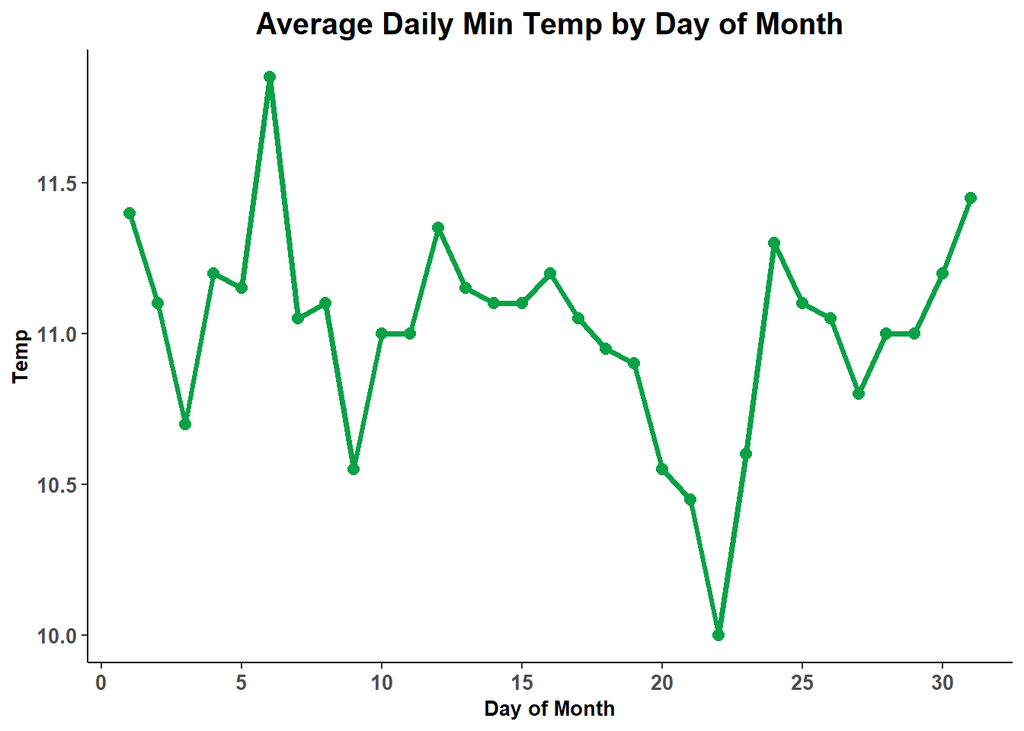

## Data preparation for modeling

Since we have a time series data for over 10 years, we can use the last 2 years of data for testing our model performance and use the remaining 8 years of data to train and tune the model. In training we use 7 years of data to train and then predict for the next 1 year to search for the best parameters and then finally fit the model on the entire training data and then predict for last two years

Here we can see how the model learned various hidden seasonal patterns

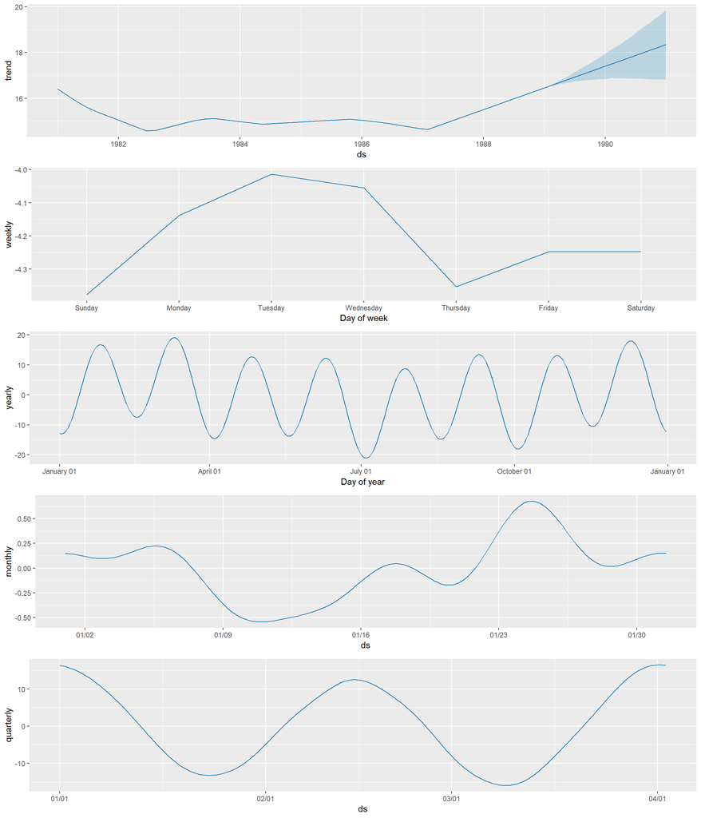